# HW3

Zian ZHUANG

## 4.2

Using the data reported in section 1.3, find the quantities specified below for the AML low risk and AML high risk groups. Note that most of these quantities are worked out in detail in Example 4.2 and its continuations for the ALL group.

### a

Estimate the survival functions and their standard errors for the AML low risk and AML high risk groups.

```r
data(bmt)

#low risk group
fit_low <- survfit(Surv(t2, d3) ~ 1, data = bmt[which(bmt$group==2),])
summary(fit_low)
```

```
## Call: survfit(formula = Surv(t2, d3) ~ 1, data = bmt[which(bmt$group ==
##     2), ])
##
##  time n.risk n.event survival std.err lower 95% CI upper 95% CI
##    10     54       1    0.981  0.0183        0.946        1.000
##    35     53       1    0.963  0.0257        0.914        1.000
##    48     52       1    0.944  0.0312        0.885        1.000
##    53     51       1    0.926  0.0356        0.859        0.998
##    79     50       1    0.907  0.0394        0.833        0.988
##    80     49       1    0.889  0.0428        0.809        0.977
##   105     48       1    0.870  0.0457        0.785        0.965
##   211     47       1    0.852  0.0483        0.762        0.952
##   219     46       1    0.833  0.0507        0.740        0.939
##   248     45       1    0.815  0.0529        0.718        0.925
##   272     44       1    0.796  0.0548        0.696        0.911
##   288     43       1    0.778  0.0566        0.674        0.897
##   381     42       1    0.759  0.0582        0.653        0.882
##   390     41       1    0.741  0.0596        0.633        0.867
##   414     40       1    0.722  0.0610        0.612        0.852
##   421     39       1    0.704  0.0621        0.592        0.837
##   481     38       1    0.685  0.0632        0.572        0.821
##   486     37       1    0.667  0.0642        0.552        0.805
##   606     36       1    0.648  0.0650        0.533        0.789
##   641     35       1    0.630  0.0657        0.513        0.773
##   704     34       1    0.611  0.0663        0.494        0.756
##   748     33       1    0.593  0.0669        0.475        0.739
##  1063     26       1    0.570  0.0681        0.451        0.720
##  1074     25       1    0.547  0.0691        0.427        0.701
##  2204      6       1    0.456  0.1012        0.295        0.704
```

```r
#high risk group
fit_high <- survfit(Surv(t2, d3) ~ 1, data = bmt[which(bmt$group==3),])
summary(fit_high)
```

```
## Call: survfit(formula = Surv(t2, d3) ~ 1, data = bmt[which(bmt$group ==
##     3), ])
##
##  time n.risk n.event survival std.err lower 95% CI upper 95% CI
##     2     45       1    0.978  0.0220        0.936        1.000
##    16     44       1    0.956  0.0307        0.897        1.000
##    32     43       1    0.933  0.0372        0.863        1.000
##    47     42       2    0.889  0.0468        0.802        0.986
##    48     40       1    0.867  0.0507        0.773        0.972
##    63     39       1    0.844  0.0540        0.745        0.957
##    64     38       1    0.822  0.0570        0.718        0.942
##    74     37       1    0.800  0.0596        0.691        0.926
##    76     36       1    0.778  0.0620        0.665        0.909
##    80     35       1    0.756  0.0641        0.640        0.892
##    84     34       1    0.733  0.0659        0.615        0.875
```

[output cut: 22 more lines]

### b

Estimate the cumulative hazard rates and their standard errors for the AML low risk and AML high risk groups.

```r
# low risk group
H.est <- cumsum(fit_low$n.event/fit_low$n.risk)
Var.est <- cumsum(fit_low$n.event/fit_low$n.risk^2)
data.frame(H.est=H.est, SE.est=sqrt(Var.est))
```

| H.est | SE.est |
| --- | --- |
| 0.01851852 | 0.01851852 |
| 0.03738644 | 0.02643736 |
| 0.05661721 | 0.03269184 |
| 0.07622506 | 0.03812118 |
| 0.09622506 | 0.04304909 |
| 0.11663322 | 0.04764155 |
| 0.13746655 | 0.05199755 |
| 0.15874315 | 0.05618219 |
| 0.18048228 | 0.06024142 |
| 0.20270450 | 0.06420947 |

[output cut: 44 more lines]

```r
# high risk group
H.est <- cumsum(fit_high$n.event/fit_high$n.risk)
Var.est <- cumsum(fit_high$n.event/fit_high$n.risk^2)
data.frame(H.est=H.est, SE.est=sqrt(Var.est))
```

| H.est | SE.est |
| --- | --- |
| 0.02222222 | 0.02222222 |
| 0.04494949 | 0.03178610 |
| 0.06820531 | 0.03938514 |
| 0.11582436 | 0.05181675 |
| 0.14082436 | 0.05753239 |
| 0.16646538 | 0.06298760 |
| 0.19278117 | 0.06826389 |
| 0.21980820 | 0.07341947 |
| 0.24758598 | 0.07849856 |
| 0.27615741 | 0.08353652 |

[output cut: 34 more lines]

### d

Estimate the mean time to death and find 95% confidence intervals for the mean survival time for both the AML low risk and AML high risk groups. (Answers are given in section 4.5.)

```r
#try hand write equation to calculate for low risk group
ind <- which(bmt$group==2&bmt$d3==1&bmt$t2<2081)
low_day <- bmt$t2[ind] %>% sort()
dif_low_day <- c(low_day[1], diff(c(low_day,2081)))
sum(dif_low_day * c(1,summary(fit_low)$sur[-25]))
```

```
## [1] 1315.179
```

```r
ind <- which(bmt$group==3&bmt$d3==1&bmt$t2<2081)
high_day <- bmt$t2[ind] %>% sort()
dif_high_day <- c(high_day[1], diff(c(high_day,2081)))
dif_high_day <- dif_high_day[which(dif_high_day!=0)]
sum(dif_high_day * c(1,summary(fit_high)$sur))
```

```
## [1] 655.6667
```

```r
# low risk group
#mean se
print(fit_low, rmean=2081)
```

```
## Call: survfit(formula = Surv(t2, d3) ~ 1, data = bmt[which(bmt$group ==
##     2), ])
##
##          n     events     *rmean *se(rmean)     median    0.95LCL    0.95UCL
##         54         25       1315        119       2204        704         NA
##     * restricted mean with upper limit =  2081
```

```r
#CI
c(1315-1.96*119, 1315+1.96*119)
```

```
## [1] 1081.76 1548.24
```

```r
high_day <- fit_high$time
dif_high_day <- c(high_day[1], diff(high_day))
sum(dif_high_day * fit_high$surv)
```

```
## [1] 776.9333
```

```r
# high risk group
#mean se
print(fit_high, rmean=2081)
```

```
## Call: survfit(formula = Surv(t2, d3) ~ 1, data = bmt[which(bmt$group ==
##     3), ])
##
##          n     events     *rmean *se(rmean)     median    0.95LCL    0.95UCL
##         45         34        656        123        183        115        456
##     * restricted mean with upper limit =  2081
```

```r
#CI
c(656-1.96*123, 656+1.96*123)
```

```
## [1] 414.92 897.08
```

### e

Work out estimates of the median time to death and find 95% confidence intervals for the median survival time for both the AML low risk and AML high risk groups using the linear, log-transformed, and arcsine formulas. (Answers are given in section 4.5.)

```r
source("functions//bc_median_ci.R")

# low risk group
bc.median.ci(fit_low, type = "linear", table = F)
```

```
## $median
## [1] 2204
##
## $lower
## [1] 704
##
## $upper
## [1] NA
##
## $type
## [1] "linear"
##
## $alpha
## [1] 0.05
```

```r
bc.median.ci(fit_low, type = "log", table = F)
```

```
## $median
## [1] 2204
##
## $lower
## [1] 641
##
## $upper
## [1] NA
##
## $type
## [1] "log"
##
## $alpha
## [1] 0.05
```

```r
bc.median.ci(fit_low, type = "asin", table = F)
```

```
## $median
## [1] 2204
##
## $lower
## [1] 641
##
## $upper
## [1] NA
##
## $type
## [1] "asin"
##
## $alpha
## [1] 0.05
```

```r
# high risk group
bc.median.ci(fit_high, type = "linear", table = F)
```

```
## $median
## [1] 183
##
## $lower
## [1] 115
##
## $upper
## [1] 363
##
## $type
## [1] "linear"
##
## $alpha
## [1] 0.05
```

```r
bc.median.ci(fit_high, type = "log", table = F)
```

```
## $median
## [1] 183
##
## $lower
## [1] 113
##
## $upper
## [1] 363
##
## $type
## [1] "log"
##
## $alpha
## [1] 0.05
```

```r
bc.median.ci(fit_high, type = "asin", table = F)
```

```
## $median
## [1] 183
##
## $lower
## [1] 115
##
## $upper
## [1] 363
##
## $type
## [1] "asin"
##
## $alpha
## [1] 0.05
```

### f

Find 95% confidence intervals for the survival functions at 300 days post-transplant for both the AML low risk and AML high risk groups using the log- and arcsine-transformed formulas.

```r
source("functions//arcsin_ci.R")
```

#### Using arcsine-transformed

AML low risk:

```r
res <- arcsin.ci(fit_low, alpha = 0.05)
res
```

| time | surv | sigma | lower | upper |
| --- | --- | --- | --- | --- |
| 10 | 0.981 | 0.019 | 0.929 | 1.000 |
| 35 | 0.963 | 0.027 | 0.897 | 0.996 |
| 48 | 0.944 | 0.033 | 0.868 | 0.989 |
| 53 | 0.926 | 0.038 | 0.842 | 0.980 |
| 79 | 0.907 | 0.043 | 0.817 | 0.969 |
| 80 | 0.889 | 0.048 | 0.792 | 0.958 |
| 105 | 0.870 | 0.053 | 0.769 | 0.946 |
| 211 | 0.852 | 0.057 | 0.746 | 0.933 |
| 219 | 0.833 | 0.061 | 0.723 | 0.920 |
| 248 | 0.815 | 0.065 | 0.701 | 0.906 |

[output cut: 44 more lines]

S(300)=S(288), then we can found that 95% confidence intervals for the survival functions is 0.778(0.658, 0.878).

AML high risk:

```r
res <- arcsin.ci(fit_high, alpha = 0.05)
res
```

| time | surv | sigma | lower | upper |
| --- | --- | --- | --- | --- |
| 2 | 0.978 | 0.022 | 0.915 | 1.000 |
| 16 | 0.956 | 0.032 | 0.877 | 0.996 |
| 32 | 0.933 | 0.040 | 0.843 | 0.987 |
| 47 | 0.889 | 0.053 | 0.782 | 0.963 |
| 48 | 0.867 | 0.058 | 0.753 | 0.949 |
| 63 | 0.844 | 0.064 | 0.725 | 0.934 |
| 64 | 0.822 | 0.069 | 0.698 | 0.919 |
| 74 | 0.800 | 0.075 | 0.672 | 0.902 |
| 76 | 0.778 | 0.080 | 0.646 | 0.886 |
| 80 | 0.756 | 0.085 | 0.621 | 0.869 |

[output cut: 34 more lines]

S(300)=S(273), then we can found that 95% confidence intervals for the survival functions is 0.422(0.283, 0.568).

#### Using log-transformed formulas.

Firstly, define a function to calculate

```r
log.ci <- function(surv.object, alpha = 0.05, events.only = FALSE) {

  #- Extract necessary values from survsurv.object object
  surv.est  <- surv.object$surv
  sigma     <- surv.object$std.err #This is sigma, not the SE of S(t)
  surv.time <- surv.object$time

  #- Get limits element wise
  lims <- data.frame(time = surv.object$time, surv = surv.est,  sigma = surv.object$std.err)

  theta <- exp(qnorm(1 - alpha / 2) * sigma / log(surv.est))
  lims$lower <- surv.est^(1/theta)
  lims$upper <- surv.est^(theta)

  if (events.only == TRUE) {
    return(round(lims[which(surv.object$n.censor == 0), ], 3))
  } else {
    return(round(lims, 3))
  }
}
```

For AML low risk:

```r
log.ci(fit_low, alpha = 0.05)
```

| time | surv | sigma | lower | upper |
| --- | --- | --- | --- | --- |
| 10 | 0.981 | 0.019 | 0.876 | 0.997 |
| 35 | 0.963 | 0.027 | 0.860 | 0.991 |
| 48 | 0.944 | 0.033 | 0.838 | 0.982 |
| 53 | 0.926 | 0.038 | 0.815 | 0.972 |
| 79 | 0.907 | 0.043 | 0.792 | 0.960 |
| 80 | 0.889 | 0.048 | 0.769 | 0.948 |
| 105 | 0.870 | 0.053 | 0.747 | 0.936 |
| 211 | 0.852 | 0.057 | 0.726 | 0.923 |
| 219 | 0.833 | 0.061 | 0.704 | 0.910 |
| 248 | 0.815 | 0.065 | 0.683 | 0.896 |

[output cut: 44 more lines]

S(300)=S(288), then we can found that 95% confidence intervals for the survival functions is 0.778(0.642, 0.867).

For AML high risk:

```r
log.ci(fit_high, alpha = 0.05)
```

| time | surv | sigma | lower | upper |
| --- | --- | --- | --- | --- |
| 2 | 0.978 | 0.022 | 0.853 | 0.997 |
| 16 | 0.956 | 0.032 | 0.834 | 0.989 |
| 32 | 0.933 | 0.040 | 0.807 | 0.978 |
| 47 | 0.889 | 0.053 | 0.753 | 0.952 |
| 48 | 0.867 | 0.058 | 0.727 | 0.938 |
| 63 | 0.844 | 0.064 | 0.701 | 0.923 |
| 64 | 0.822 | 0.069 | 0.676 | 0.907 |
| 74 | 0.800 | 0.075 | 0.651 | 0.891 |
| 76 | 0.778 | 0.080 | 0.626 | 0.874 |
| 80 | 0.756 | 0.085 | 0.602 | 0.856 |

[output cut: 34 more lines]

S(300)=S(273), then we can found that 95% confidence intervals for the survival functions is 0.422(0.278, 0.560).

#### likelihood ratio method

For AML low risk:

```r
source("functions//LRci.R")
LRci.surv(fit_low, t = 300)
```

```
## $time
## [1] 300
##
## $surv.est
## [1] 0.778
##
## $conf.int
##         LL    UL
## [1,] 0.656 0.874
##
## $alpha
## [1] 0.05
```

For AML high risk:

```r
LRci.surv(fit_high, t = 300)
```

```
## $time
## [1] 300
##
## $surv.est
## [1] 0.422
##
## $conf.int
##         LL    UL
## [1,] 0.285 0.568
##
## $alpha
## [1] 0.05
```

#### bootstrap method

```r
source("functions//SurvivalProb_boots.R")
Low_group <- bmt[which(bmt$group==2),]
High_group <- bmt[which(bmt$group==3),]
```

For AML low risk:

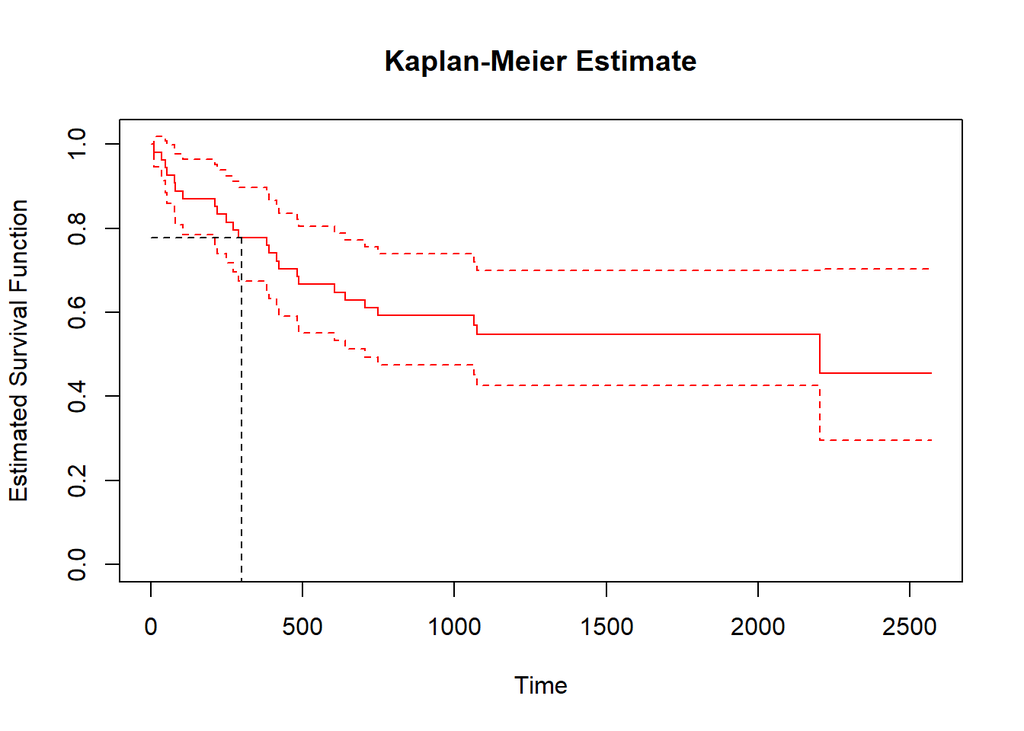

```
## $Time
## [1] 300
##
## $`Survival Probability Estimate`
## [1] 0.7777778
##
## $`Std. Err`
## [1] 0.05581138
```

```r
SurvivalProb_boots(Low_group$t2, Low_group$d3, 300, plots = TRUE)
```

Then we can calculate the 95%CI

```r
c(0.7777778-1.96*0.05521416, 0.7777778+1.96*0.05521416)
```

```
## [1] 0.6695580 0.8859976
```

For AML high risk:

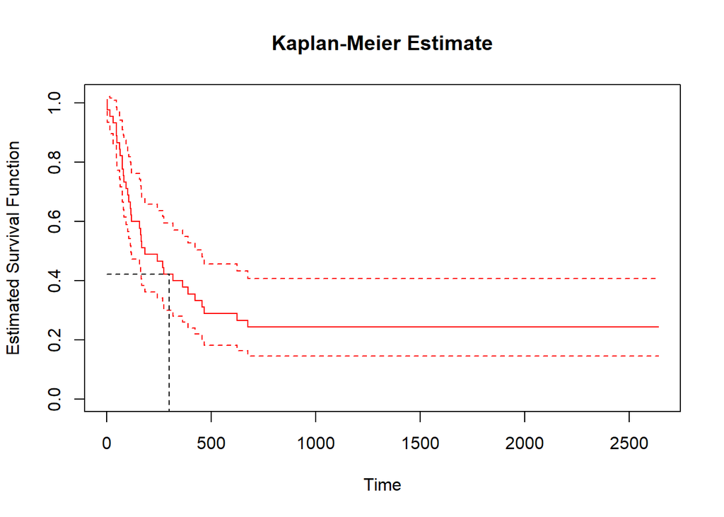

```
## $Time
## [1] 300
##
## $`Survival Probability Estimate`
## [1] 0.4222222
##
## $`Std. Err`
## [1] 0.07656113
```

```r
SurvivalProb_boots(High_group$t2, High_group$d3, 300, plots = TRUE)
```

Then we can calculate the 95%CI

```r
c(0.4222222-1.96*0.07486193, 0.4222222+1.96*0.07486193)
```

```
## [1] 0.2754928 0.5689516
```

### g

Find 95% EP confidence bands for the survival functions over the range 100–400 days post-transplant for both the AML low risk and AML high risk groups using the linear, log-transformed, and arcsinetransformed formulas.

```r
source("functions\\conf_bands.R")
```

#### AML low risk

```r
#calculate critical regions first
cbands.region(fit_low, 100, 400)
```

```
## Find critical regions in Klein and Moeschberger 2nd ed. (Appendix C.3a - C.4c)
```

```
## $aL
## [1] 0.11
##
## $aU
## [1] 0.26
```

linear

```r
cbands.interval(fit_low, 100, 400, crit.value=(2.6430+2.5949)/2,
                alpha = 0.05, type = "linear", method = "ep")
```

```
## Returning linear-type confidence bands using ep method.
```

|  | t | surv | se | LL | UL |
| --- | --- | --- | --- | --- | --- |
| 1 | 80 | 0.889 | 0.048 | 0.777 | 1.001 |
| 2 | 105 | 0.870 | 0.053 | 0.751 | 0.990 |
| 3 | 211 | 0.852 | 0.057 | 0.725 | 0.978 |
| 4 | 219 | 0.833 | 0.061 | 0.701 | 0.966 |
| 5 | 248 | 0.815 | 0.065 | 0.676 | 0.953 |
| 6 | 272 | 0.796 | 0.069 | 0.653 | 0.940 |
| 7 | 288 | 0.778 | 0.073 | 0.630 | 0.926 |
| 8 | 381 | 0.759 | 0.077 | 0.607 | 0.912 |
| 9 | 390 | 0.741 | 0.081 | 0.585 | 0.897 |

arcsinetransformed

```r
cbands.interval(fit_low, 100, 400, crit.value=(2.6430+2.5949)/2,
                alpha = 0.05, type = "asin", method = "ep")
```

```
## Returning asin-type confidence bands using ep method.
```

|  | t | surv | se | LL | UL |
| --- | --- | --- | --- | --- | --- |
| 1 | 80 | 0.889 | 0.048 | 0.755 | 0.974 |
| 2 | 105 | 0.870 | 0.053 | 0.730 | 0.964 |
| 3 | 211 | 0.852 | 0.057 | 0.706 | 0.954 |
| 4 | 219 | 0.833 | 0.061 | 0.682 | 0.942 |
| 5 | 248 | 0.815 | 0.065 | 0.660 | 0.931 |
| 6 | 272 | 0.796 | 0.069 | 0.637 | 0.918 |
| 7 | 288 | 0.778 | 0.073 | 0.615 | 0.905 |
| 8 | 381 | 0.759 | 0.077 | 0.594 | 0.892 |
| 9 | 390 | 0.741 | 0.081 | 0.573 | 0.879 |

log-transformed

```r
cbands.interval(fit_low, 100, 400, crit.value=(2.6430+2.5949)/2,
                alpha = 0.05, type = "log", method = "ep")
```

```
## Returning log-type confidence bands using ep method.
```

|  | t | surv | se | LL | UL |
| --- | --- | --- | --- | --- | --- |
| 1 | 80 | 0.889 | 0.048 | 0.709 | 0.960 |
| 2 | 105 | 0.870 | 0.053 | 0.688 | 0.950 |
| 3 | 211 | 0.852 | 0.057 | 0.667 | 0.939 |
| 4 | 219 | 0.833 | 0.061 | 0.646 | 0.927 |
| 5 | 248 | 0.815 | 0.065 | 0.625 | 0.915 |
| 6 | 272 | 0.796 | 0.069 | 0.605 | 0.902 |
| 7 | 288 | 0.778 | 0.073 | 0.585 | 0.889 |
| 8 | 381 | 0.759 | 0.077 | 0.565 | 0.876 |
| 9 | 390 | 0.741 | 0.081 | 0.546 | 0.862 |

#### AML high risk

```r
#calculate critical regions first
cbands.region(fit_high, 100, 400)
```

```
## Find critical regions in Klein and Moeschberger 2nd ed. (Appendix C.3a - C.4c)
```

```
## $aL
## [1] 0.31
##
## $aU
## [1] 0.64
```

```r
2.6998+2.6811
```

```
## [1] 5.3809
```

linear

```r
cbands.interval(fit_high, 100, 400, crit.value=(2.6998+2.6811)/2,
                alpha = 0.05, type = "linear", method = "ep")
```

```
## Returning linear-type confidence bands using ep method.
```

|  | t | surv | se | LL | UL |
| --- | --- | --- | --- | --- | --- |
| 1 | 100 | 0.689 | 0.100 | 0.503 | 0.875 |
| 2 | 105 | 0.667 | 0.105 | 0.478 | 0.856 |
| 3 | 113 | 0.644 | 0.111 | 0.452 | 0.836 |
| 4 | 115 | 0.622 | 0.116 | 0.428 | 0.817 |
| 5 | 120 | 0.600 | 0.122 | 0.404 | 0.796 |
| 6 | 157 | 0.578 | 0.127 | 0.380 | 0.776 |
| 7 | 162 | 0.556 | 0.133 | 0.356 | 0.755 |
| 8 | 164 | 0.533 | 0.139 | 0.333 | 0.733 |
| 9 | 168 | 0.511 | 0.146 | 0.311 | 0.712 |
| 10 | 183 | 0.489 | 0.152 | 0.288 | 0.689 |

[output cut: 6 more lines]

arcsinetransformed

```r
cbands.interval(fit_high, 100, 400, crit.value=(2.6998+2.6811)/2,
                alpha = 0.05, type = "asin", method = "ep")
```

```
## Returning asin-type confidence bands using ep method.
```

|  | t | surv | se | LL | UL |
| --- | --- | --- | --- | --- | --- |
| 1 | 100 | 0.689 | 0.100 | 0.493 | 0.855 |
| 2 | 105 | 0.667 | 0.105 | 0.469 | 0.837 |
| 3 | 113 | 0.644 | 0.111 | 0.446 | 0.820 |
| 4 | 115 | 0.622 | 0.116 | 0.423 | 0.802 |
| 5 | 120 | 0.600 | 0.122 | 0.401 | 0.783 |
| 6 | 157 | 0.578 | 0.127 | 0.379 | 0.764 |
| 7 | 162 | 0.556 | 0.133 | 0.357 | 0.745 |
| 8 | 164 | 0.533 | 0.139 | 0.336 | 0.725 |
| 9 | 168 | 0.511 | 0.146 | 0.315 | 0.705 |
| 10 | 183 | 0.489 | 0.152 | 0.295 | 0.685 |

[output cut: 6 more lines]

log-transformed

```r
cbands.interval(fit_high, 100, 400, crit.value=(2.6998+2.6811)/2,
                alpha = 0.05, type = "log", method = "ep")
```

```
## Returning log-type confidence bands using ep method.
```

|  | t | surv | se | LL | UL |
| --- | --- | --- | --- | --- | --- |
| 1 | 100 | 0.689 | 0.100 | 0.464 | 0.835 |
| 2 | 105 | 0.667 | 0.105 | 0.442 | 0.818 |
| 3 | 113 | 0.644 | 0.111 | 0.421 | 0.800 |
| 4 | 115 | 0.622 | 0.116 | 0.400 | 0.782 |
| 5 | 120 | 0.600 | 0.122 | 0.379 | 0.764 |
| 6 | 157 | 0.578 | 0.127 | 0.359 | 0.746 |
| 7 | 162 | 0.556 | 0.133 | 0.339 | 0.727 |
| 8 | 164 | 0.533 | 0.139 | 0.319 | 0.707 |
| 9 | 168 | 0.511 | 0.146 | 0.300 | 0.688 |
| 10 | 183 | 0.489 | 0.152 | 0.281 | 0.668 |

[output cut: 6 more lines]

### h

Find 95% HW confidence bands for the survival functions over the range 100–400 days post-transplant for both the AML low risk and AML high risk groups using the linear, log-transformed, and arcsinetransformed formulas.

#### AML low risk

```r
#calculate critical regions first
cbands.region(fit_low, 100, 400)
```

```
## Find critical regions in Klein and Moeschberger 2nd ed. (Appendix C.3a - C.4c)
```

```
## $aL
## [1] 0.11
##
## $aU
## [1] 0.26
```

linear

```r
cbands.interval(fit_low, 100, 400, crit.value=(1.0294+1.0281)/2,
                alpha = 0.05, type = "linear", method = "hw")
```

```
## Returning linear-type confidence bands using hw method.
```

|  | t | surv | se | LL | UL |
| --- | --- | --- | --- | --- | --- |
| 1 | 80 | 0.889 | 0.048 | 0.749 | 1.029 |
| 2 | 105 | 0.870 | 0.053 | 0.730 | 1.010 |
| 3 | 211 | 0.852 | 0.057 | 0.712 | 0.992 |
| 4 | 219 | 0.833 | 0.061 | 0.693 | 0.973 |
| 5 | 248 | 0.815 | 0.065 | 0.675 | 0.955 |
| 6 | 272 | 0.796 | 0.069 | 0.656 | 0.936 |
| 7 | 288 | 0.778 | 0.073 | 0.638 | 0.918 |
| 8 | 381 | 0.759 | 0.077 | 0.619 | 0.899 |
| 9 | 390 | 0.741 | 0.081 | 0.601 | 0.881 |

arcsinetransformed

```r
cbands.interval(fit_low, 100, 400, crit.value=(1.0294+1.0281)/2,
                alpha = 0.05, type = "asin", method = "hw")
```

```
## Returning asin-type confidence bands using hw method.
```

|  | t | surv | se | LL | UL |
| --- | --- | --- | --- | --- | --- |
| 1 | 80 | 0.889 | 0.048 | 0.716 | 0.986 |
| 2 | 105 | 0.870 | 0.053 | 0.703 | 0.975 |
| 3 | 211 | 0.852 | 0.057 | 0.688 | 0.961 |
| 4 | 219 | 0.833 | 0.061 | 0.673 | 0.947 |
| 5 | 248 | 0.815 | 0.065 | 0.658 | 0.932 |
| 6 | 272 | 0.796 | 0.069 | 0.641 | 0.916 |
| 7 | 288 | 0.778 | 0.073 | 0.625 | 0.900 |
| 8 | 381 | 0.759 | 0.077 | 0.608 | 0.883 |
| 9 | 390 | 0.741 | 0.081 | 0.591 | 0.866 |

log-transformed

```r
cbands.interval(fit_low, 100, 400, crit.value=(1.0294+1.0281)/2,
                alpha = 0.05, type = "log", method = "hw")
```

```
## Returning log-type confidence bands using hw method.
```

|  | t | surv | se | LL | UL |
| --- | --- | --- | --- | --- | --- |
| 1 | 80 | 0.889 | 0.048 | 0.639 | 0.970 |
| 2 | 105 | 0.870 | 0.053 | 0.643 | 0.957 |
| 3 | 211 | 0.852 | 0.057 | 0.640 | 0.944 |
| 4 | 219 | 0.833 | 0.061 | 0.632 | 0.930 |
| 5 | 248 | 0.815 | 0.065 | 0.623 | 0.915 |
| 6 | 272 | 0.796 | 0.069 | 0.611 | 0.900 |
| 7 | 288 | 0.778 | 0.073 | 0.598 | 0.884 |
| 8 | 381 | 0.759 | 0.077 | 0.584 | 0.868 |
| 9 | 390 | 0.741 | 0.081 | 0.569 | 0.852 |

#### AML high risk

```r
#calculate critical regions first
cbands.region(fit_high, 100, 400)
```

```
## Find critical regions in Klein and Moeschberger 2nd ed. (Appendix C.3a - C.4c)
```

```
## $aL
## [1] 0.31
##
## $aU
## [1] 0.64
```

linear

```r
cbands.interval(fit_high, 100, 400, crit.value=(1.3201+1.3155)/2,
                alpha = 0.05, type = "linear", method = "hw")
```

```
## Returning linear-type confidence bands using hw method.
```

|  | t | surv | se | LL | UL |
| --- | --- | --- | --- | --- | --- |
| 1 | 100 | 0.689 | 0.100 | 0.492 | 0.886 |
| 2 | 105 | 0.667 | 0.105 | 0.469 | 0.864 |
| 3 | 113 | 0.644 | 0.111 | 0.447 | 0.842 |
| 4 | 115 | 0.622 | 0.116 | 0.425 | 0.819 |
| 5 | 120 | 0.600 | 0.122 | 0.403 | 0.797 |
| 6 | 157 | 0.578 | 0.127 | 0.381 | 0.775 |
| 7 | 162 | 0.556 | 0.133 | 0.359 | 0.752 |
| 8 | 164 | 0.533 | 0.139 | 0.337 | 0.730 |
| 9 | 168 | 0.511 | 0.146 | 0.315 | 0.708 |
| 10 | 183 | 0.489 | 0.152 | 0.292 | 0.685 |

[output cut: 6 more lines]

arcsinetransformed

```r
cbands.interval(fit_high, 100, 400, crit.value=(1.3201+1.3155)/2,
                alpha = 0.05, type = "asin", method = "hw")
```

```
## Returning asin-type confidence bands using hw method.
```

|  | t | surv | se | LL | UL |
| --- | --- | --- | --- | --- | --- |
| 1 | 100 | 0.689 | 0.100 | 0.481 | 0.863 |
| 2 | 105 | 0.667 | 0.105 | 0.461 | 0.844 |
| 3 | 113 | 0.644 | 0.111 | 0.441 | 0.824 |
| 4 | 115 | 0.622 | 0.116 | 0.421 | 0.804 |
| 5 | 120 | 0.600 | 0.122 | 0.400 | 0.784 |
| 6 | 157 | 0.578 | 0.127 | 0.380 | 0.763 |
| 7 | 162 | 0.556 | 0.133 | 0.360 | 0.743 |
| 8 | 164 | 0.533 | 0.139 | 0.339 | 0.722 |
| 9 | 168 | 0.511 | 0.146 | 0.319 | 0.702 |
| 10 | 183 | 0.489 | 0.152 | 0.298 | 0.681 |

[output cut: 6 more lines]

log-transformed

```r
cbands.interval(fit_high, 100, 400, crit.value=(1.3201+1.3155)/2,
                alpha = 0.05, type = "log", method = "hw")
```

```
## Returning log-type confidence bands using hw method.
```

|  | t | surv | se | LL | UL |
| --- | --- | --- | --- | --- | --- |
| 1 | 100 | 0.689 | 0.100 | 0.448 | 0.841 |
| 2 | 105 | 0.667 | 0.105 | 0.431 | 0.822 |
| 3 | 113 | 0.644 | 0.111 | 0.414 | 0.803 |
| 4 | 115 | 0.622 | 0.116 | 0.397 | 0.784 |
| 5 | 120 | 0.600 | 0.122 | 0.379 | 0.764 |
| 6 | 157 | 0.578 | 0.127 | 0.360 | 0.745 |
| 7 | 162 | 0.556 | 0.133 | 0.342 | 0.725 |
| 8 | 164 | 0.533 | 0.139 | 0.323 | 0.705 |
| 9 | 168 | 0.511 | 0.146 | 0.304 | 0.685 |
| 10 | 183 | 0.489 | 0.152 | 0.285 | 0.665 |

[output cut: 6 more lines]

### i

Based on the results above and those discussed in Example 4.2 and its continuations, how do the survival experiences of the ALL, AML low risk, and AML high risk groups compare?

```r
survdiff(Surv(t2, d3) ~ group, data=bmt)
```

```
## Call:
## survdiff(formula = Surv(t2, d3) ~ group, data = bmt)
##
##          N Observed Expected (O-E)^2/E (O-E)^2/V
## group=1 38       24     21.9     0.211     0.289
## group=2 54       25     40.0     5.604    11.012
## group=3 45       34     21.2     7.756    10.529
##
##  Chisq= 13.8  on 2 degrees of freedom, p= 0.001
```

As we can tell from the results above and those discussed in Example 4.2 and its continuations, AML low risk has the highest estimated mean&median survival probability and AML high risk has the lowest estimated mean&median survival probability. All estimate methods provided consistent answers. In addition, the difference is significant according to the Log-Rank Test.

## 4.7

Consider a hypothetical study of the mortality experience of diabetics. Thirty diabetic subjects are recruited at a clinic and followed until death or the end of the study. The subject’s age at entry into the study and their age at the end of study or death are given in the table below. Of interest is estimating the survival curve for a 60- or for a 70-year-old diabetic

### a

Since the diabetics needed to survive long enough from birth until the study began, the data is left truncated. Construct a table showing the number of subjects at risk, Y , as a function of age.

```r
(df<-data.frame(time=c(58:74,76:80),
               Y=c(2,3,5,6,9,10,10,10,10,12,13,14,13,12,12,11,9,7,5,4,3,1)))
```

| time | Y |
| --- | --- |
| 58 | 2 |
| 59 | 3 |
| 60 | 5 |
| 61 | 6 |
| 62 | 9 |
| 63 | 10 |
| 64 | 10 |
| 65 | 10 |
| 66 | 10 |
| 67 | 12 |

[output cut: 12 more lines]

### b

Estimate the conditional survival function for the age of death of a diabetic patient who has survived to age 60.

```r
df %>%
  mutate(n = c(2,3,4,6,8,9,10,8,9,12,11,12,11,10,10,10,8,6,4,4,3,1)) %>%
  mutate(S_60 = cumprod(n/Y))
```

| time | Y | n | S_60 |
| --- | --- | --- | --- |
| 58 | 2 | 2 | 1.0000000 |
| 59 | 3 | 3 | 1.0000000 |
| 60 | 5 | 4 | 0.8000000 |
| 61 | 6 | 6 | 0.8000000 |
| 62 | 9 | 8 | 0.7111111 |
| 63 | 10 | 9 | 0.6400000 |
| 64 | 10 | 10 | 0.6400000 |
| 65 | 10 | 8 | 0.5120000 |
| 66 | 10 | 9 | 0.4608000 |
| 67 | 12 | 12 | 0.4608000 |

[output cut: 12 more lines]

### c

Estimate the conditional survival function for the age of death of a diabetic patient who has survived to age 70.

```r
df %>%
  mutate(n = c(2,3,4,6,8,9,10,8,9,12,11,12,11,10,10,10,8,6,4,4,3,1)) %>%
  mutate(S_60 = cumprod(c(rep(1,12),(n/Y)[-c(1:12)])))
```

| time | Y | n | S_60 |
| --- | --- | --- | --- |
| 58 | 2 | 2 | 1.0000000 |
| 59 | 3 | 3 | 1.0000000 |
| 60 | 5 | 4 | 1.0000000 |
| 61 | 6 | 6 | 1.0000000 |
| 62 | 9 | 8 | 1.0000000 |
| 63 | 10 | 9 | 1.0000000 |
| 64 | 10 | 10 | 1.0000000 |
| 65 | 10 | 8 | 1.0000000 |
| 66 | 10 | 9 | 1.0000000 |
| 67 | 12 | 12 | 1.0000000 |

[output cut: 12 more lines]

### d

Suppose an investigator incorrectly ignored the left truncation and simply treated the data as right censored. Repeat parts a–c

```r
(df<-data.frame(time=c(58:74,76:80),
                Y=c(rep(30,3),29,29,28,27,27,25,24,24,22,18,16,14,11,9,7,5,4,3,1)))
```

| time | Y |
| --- | --- |
| 58 | 30 |
| 59 | 30 |
| 60 | 30 |
| 61 | 29 |
| 62 | 29 |
| 63 | 28 |
| 64 | 27 |
| 65 | 27 |
| 66 | 25 |
| 67 | 24 |

[output cut: 12 more lines]

```r
df %>%
  mutate(n=Y-c(0,0,1,0,1,1,0,2,1,0,2,2,2,2,2,1,1,1,1,0,0,0)) %>%
  mutate(S_60 = cumprod(n/Y))
```

| time | Y | n | S_60 |
| --- | --- | --- | --- |
| 58 | 30 | 30 | 1.0000000 |
| 59 | 30 | 30 | 1.0000000 |
| 60 | 30 | 29 | 0.9666667 |
| 61 | 29 | 29 | 0.9666667 |
| 62 | 29 | 28 | 0.9333333 |
| 63 | 28 | 27 | 0.9000000 |
| 64 | 27 | 27 | 0.9000000 |
| 65 | 27 | 25 | 0.8333333 |
| 66 | 25 | 24 | 0.8000000 |
| 67 | 24 | 24 | 0.8000000 |

[output cut: 12 more lines]

```r
df %>%
  mutate(n=Y-c(0,0,1,0,1,1,0,2,1,0,2,2,2,2,2,1,1,1,1,0,0,0)) %>%
  mutate(S_60 = cumprod(c(rep(1,12),(n/Y)[-c(1:12)])))
```

| time | Y | n | S_60 |
| --- | --- | --- | --- |
| 58 | 30 | 30 | 1.0000000 |
| 59 | 30 | 30 | 1.0000000 |
| 60 | 30 | 29 | 1.0000000 |
| 61 | 29 | 29 | 1.0000000 |
| 62 | 29 | 28 | 1.0000000 |
| 63 | 28 | 27 | 1.0000000 |
| 64 | 27 | 27 | 1.0000000 |
| 65 | 27 | 25 | 1.0000000 |
| 66 | 25 | 24 | 1.0000000 |
| 67 | 24 | 24 | 1.0000000 |

[output cut: 12 more lines]